# HW7

葛宇泽 19307130176

2021/11/30

## 1. 读入数据并了解各个自变量的含义

```r
setwd("F:/2021秋季/机器学习/HW6")
data = read.csv("simudata.csv",sep=",",fileEncoding = 'UTF-8',head=T)
data$black = factor(data$black)
summary(data)
```

```
##      creded           debitF          meanpay           billnum
##  Min.   :0.0000   Min.   :  0.00   Min.   :      0   Min.   :  0.00
##  1st Qu.:0.0200   1st Qu.:  5.00   1st Qu.:  50475   1st Qu.: 11.00
##  Median :0.1000   Median : 25.00   Median : 231277   Median : 55.00
##  Mean   :0.1448   Mean   : 35.46   Mean   : 271800   Mean   : 74.47
##  3rd Qu.:0.2400   3rd Qu.: 57.00   3rd Qu.: 425342   3rd Qu.:119.00
##  Max.   :0.8200   Max.   :202.00   Max.   :1346594   Max.   :427.00
##      debitM          zhongxingM          sidaM            xindaiR
##  Min.   :     26   Min.   :      3   Min.   :     10   Min.   :  0.02
##  1st Qu.:  59310   1st Qu.:  21617   1st Qu.:  44692   1st Qu.: 70.17
##  Median : 264838   Median :  97913   Median : 219769   Median :155.52
##  Mean   : 305073   Mean   : 161771   Mean   : 271535   Mean   :163.34
##  3rd Qu.: 479646   3rd Qu.: 261094   3rd Qu.: 433841   3rd Qu.:241.02
##  Max.   :1436086   Max.   :1017770   Max.   :1299826   Max.   :365.00
##     cardnum          xindaiF          maxpay         zhuanzhangF
##  Min.   : 0.000   Min.   : 0.00   Min.   :      9   Min.   :  0.00
##  1st Qu.: 3.000   1st Qu.: 1.00   1st Qu.: 277166   1st Qu.:  3.00
##  Median : 6.000   Median : 4.00   Median :1182465   Median : 14.00
##  Mean   : 6.395   Mean   : 4.16   Mean   :1370679   Mean   : 22.19
##  3rd Qu.: 9.000   3rd Qu.: 7.00   3rd Qu.:2138145   3rd Qu.: 36.00
##  Max.   :26.000   Max.   :20.00   Max.   :6470316   Max.   :124.00
##    gongjiaoF       zhuanzhangR          age          gongjiaoR
##  Min.   :0.0000   Min.   :  0.28   Min.   :14.00   Min.   :206.3
##  1st Qu.:0.0000   1st Qu.:126.08   1st Qu.:27.00   1st Qu.:332.8
##  Median :0.0000   Median :219.46   Median :30.00   Median :359.5
##  Mean   :0.9369   Mean   :223.06   Mean   :29.98   Mean   :346.4
##  3rd Qu.:2.0000   3rd Qu.:308.47   3rd Qu.:33.00   3rd Qu.:365.0
##  Max.   :7.0000   Max.   :704.05   Max.   :47.00   Max.   :365.0
##      sidaF            sidaR          zhongxingF       zhongxingR
##  Min.   :  0.00   Min.   :  0.16   Min.   : 0.000   Min.   :  0.17
##  1st Qu.:  4.00   1st Qu.: 57.22   1st Qu.: 1.000   1st Qu.:157.15
##  Median : 17.00   Median :136.13   Median : 5.000   Median :251.33
##  Mean   : 25.26   Mean   :148.53   Mean   : 7.812   Mean   :237.54
##  3rd Qu.: 42.00   3rd Qu.:219.95   3rd Qu.:13.000   3rd Qu.:340.05
##  Max.   :144.00   Max.   :365.00   Max.   :53.000   Max.   :365.00
##     xiaofeiF          jinkaF        zhuanzhangM          gongjiaoM
##  Min.   : 0.000   Min.   : 0.000   Min.   :     38.2   Min.   :    0.02
##  1st Qu.: 0.000   1st Qu.: 1.000   1st Qu.:  45837.9   1st Qu.:  804.83
##  Median : 1.000   Median : 3.000   Median : 214517.8   Median : 2245.55
##  Mean   : 2.578   Mean   : 6.101   Mean   : 304697.9   Mean   : 6079.25
##  3rd Qu.: 4.000   3rd Qu.:10.000   3rd Qu.: 496300.3   3rd Qu.: 9483.37
##  Max.   :19.000   Max.   :44.000   Max.   :1650050.4   Max.   :55745.07
##      youxiM           xindaiS         black
##  Min.   :   0.00   Min.   :     8.1   0:5352
##  1st Qu.:  28.05   1st Qu.: 18240.0   1:2680
##  Median :  75.05   Median : 87971.4
##  Mean   : 209.64   Mean   :106103.7
##  3rd Qu.: 329.99   3rd Qu.:165942.2
##  Max.   :1939.00   Max.   :485178.3
```

读入数据并汇总。自变量名称中结尾大写字母R表示最近一次消费到现在的时间距离，F表示消费频率，M表示平均消费金额，S衡量用户行为的波动性。

由black均值为0.3337可知，违约用户占比为33.37%，违约用户与未违约用户比例约为1：2。

## 2. 按照7:3划分训练集和测试集，用多种机器学习模型进行建模；在测试集上进行测试，绘制ROC曲线，计算AUC值。

首先按7:3划分训练集和测试集

```r
#划分数据
set.seed(1234)
index = sample(nrow(data),0.7*nrow(data))
train_set = data[index,]
test_set = data[-index,]
```

### 逻辑回归模型

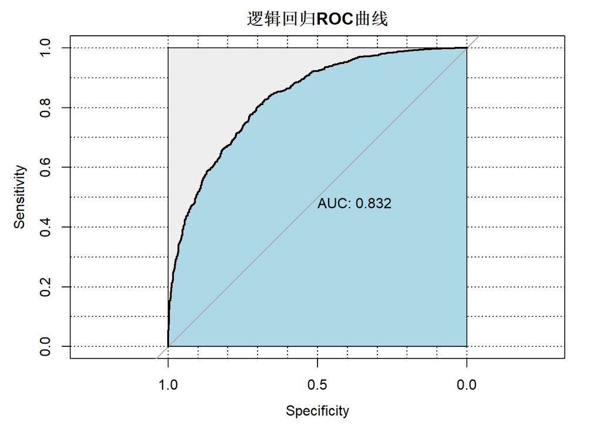

```r
suppressMessages(library(rpart))
suppressMessages(library(rpart.plot))
suppressMessages(library(pROC))

log.model = glm(formula = black~.,family = binomial(link = logit),data=train_set)
log.pred = predict(log.model,test_set,type='response')
log.roc = roc(test_set$black,log.pred)
plot(log.roc,print.auc=T,grid=c(T,T),grid.col=c("black","black"),main='逻辑回归ROC曲线',
     auc.polygon=T,auc.polygon.col='lightblue',max.auc.polygon=T)
```

### 决策树模型

```r
detree = rpart(black~.,data = train_set)
predtree = predict(detree,newdata=test_set)
tree.roc = roc(test_set$black,predtree[,2])
```

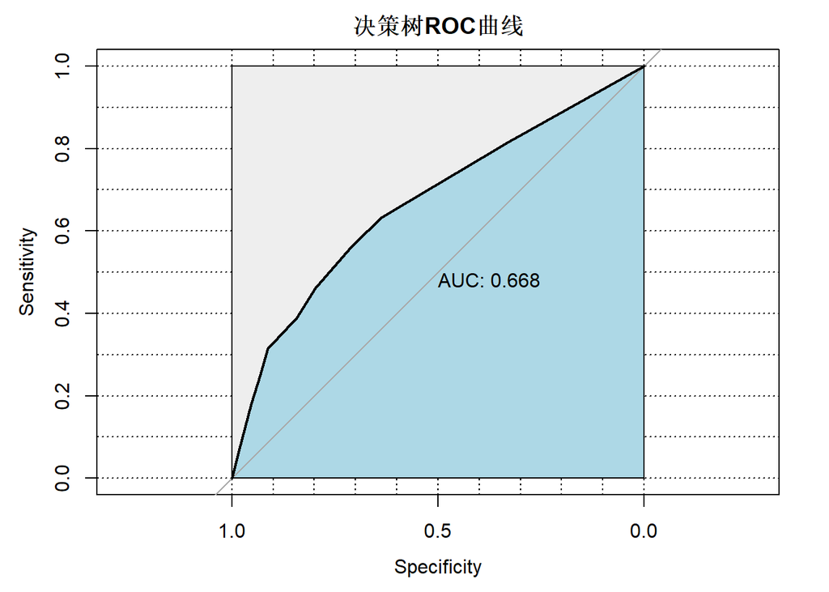

```r
plot(tree.roc,print.auc=T,grid=c(T,T),grid.col=c("black","black"),main='决策树ROC曲线',
     auc.polygon=T,auc.polygon.col='lightblue',max.auc.polygon=T)
```

### Boosting模型

```r
suppressMessages(library(adabag))
boosting.model = boosting(black~.,data = train_set)
boosting.pred = predict(boosting.model,newdata = test_set,type='prob')
boosting.roc = roc(test_set$black,boosting.pred$prob[,2])
```

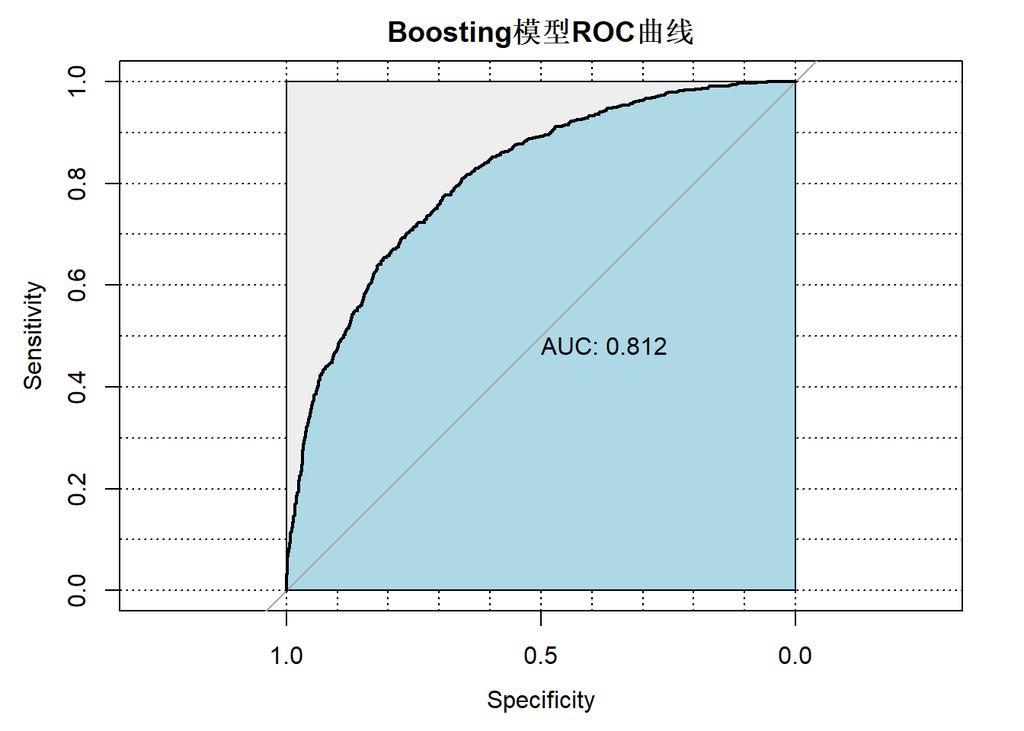

```r
plot(boosting.roc,print.auc=T,grid=c(T,T),grid.col=c("black","black"),main='Boosting模型ROC曲线',
     auc.polygon=T,auc.polygon.col='lightblue',max.auc.polygon=T)
```

### 随机森林模型

```r
suppressMessages(library(randomForest))
rf.model = randomForest(black~.,data=train_set)
rf.pred = predict(rf.model,newdata = test_set,type='prob')
rf.roc = roc(test_set$black,rf.pred[,2])
```

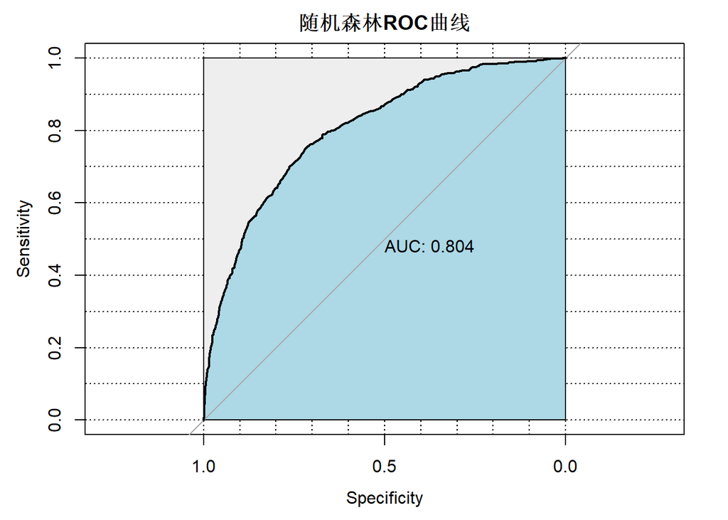

```r
plot(rf.roc,print.auc=T,grid=c(T,T),grid.col=c("black","black"),main='随机森林ROC曲线',
     auc.polygon=T,auc.polygon.col='lightblue',max.auc.polygon=T)
```

### SVM模型

```r
suppressMessages(library(e1071))
svm.model = svm(black~.,data=train_set,prob=TRUE)
svm.pred = predict(svm.model,newdata=test_set,prob=TRUE)
svm.roc = roc(test_set$black,attr(svm.pred, "probabilities")[,2])
```

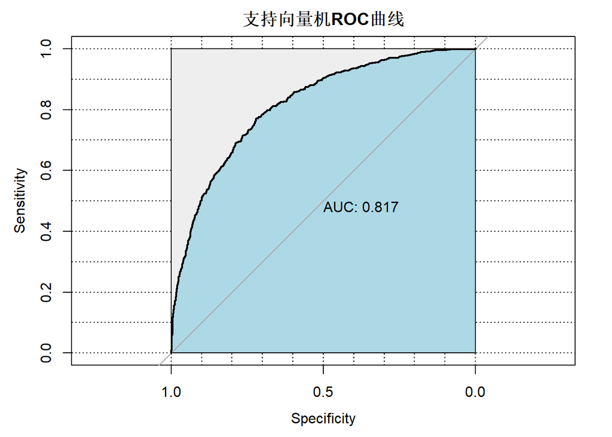

```r
plot(svm.roc,print.auc=T,grid=c(T,T),grid.col=c("black","black"),main='支持向量机ROC曲线',
     auc.polygon=T,auc.polygon.col='lightblue',max.auc.polygon=T)
```

## 3.对比以上模型的AUC值和ROC曲线，选择一个最优的模型，并说明理由。

```r
vauc = c(round(log.roc$auc,3),round(tree.roc$auc,3),round(boosting.roc$auc,3),
         round(rf.roc$auc,3),round(svm.roc$auc,3))
vnames = c("逻辑回归",'决策树','Boosting','随机森林','支持向量机')
vauc2 = data.frame(vauc=vauc,vnames=vnames)
```

对比各模型的ROC曲线

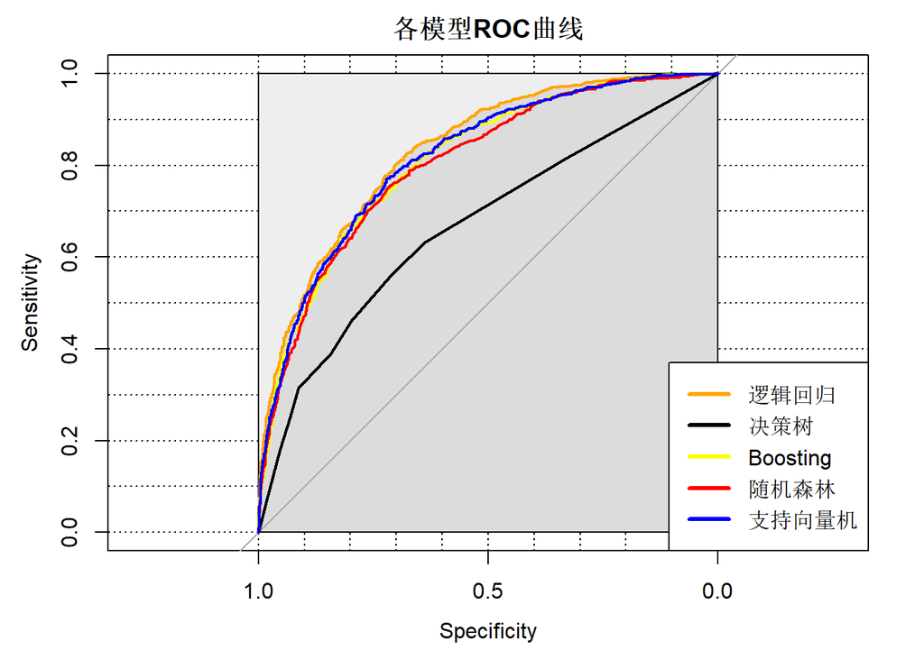

```r
plot(log.roc,grid=c(T,T),grid.col=c("black","black"),main='各模型ROC曲线',
     auc.polygon=T,max.auc.polygon=T,col='orange')
plot(tree.roc,add=TRUE,col='black')
plot(boosting.roc,add=TRUE,col='yellow')
plot(rf.roc,add=TRUE,col='red')
plot(svm.roc,add=TRUE,col='blue')
legend("bottomright",legend=c("逻辑回归","决策树","Boosting","随机森林","支持向量机"),
       col=c("orange","black","yellow","red","blue"),lty=1,lwd=3)
```

画出各模型AUC值的柱状图

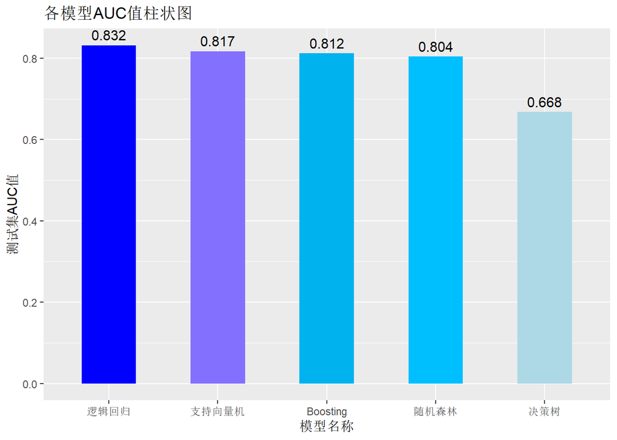

```r
library(ggplot2)
ggplot(vauc2,aes(x=reorder(vnames,-vauc),y=vauc)) +
        geom_bar(width = 0.5,stat='identity',fill=c("blue","lightblue","deepskyblue2","deepskyblue","lightslateblue")) +
        labs(x='模型名称',y='测试集AUC值',title='各模型AUC值柱状图') +
        geom_text(mapping = aes(label = vauc), size = 4, vjust = -0.5)
```

整理得到各模型对应的AUC值:

| 模型 | AUC |
| --- | --- |
| 逻辑回归 | 0.832 |
| 支持向量机 | 0.817 |
| Boosting | 0.812 |
| 随机森林 | 0.804 |
| 决策树 | 0.668 |

选择逻辑回归模型作为最优模型。逻辑回归模型的AUC值最高，为0.832；且从各模型ROC曲线曲线图中可以看出，逻辑回归模型的ROC曲线大致包裹了其他模型的ROC曲线。这说明逻辑回归模型对该问题在测试集上分类正确率最高，泛化能力强。另外，在AUC值相近的几种模型中，逻辑回归模型的生成速度最快。SVM及集成学习方法的模型生成时间都比较长。所以选择逻辑回归作为最优模型。

在五种模型中，决策树的AUC最低，为0.668，模型效果不够理想。其他4种模型效果相近，AUC均在0.8以上， 模型效果较好。其中，Boosting和随机森林采用了集成学习方法，将多个弱分类器组合成强分类器，最终得到了较好的效果。

```r
summary(log.model)
```

```
##
## Call:
## glm(formula = black ~ ., family = binomial(link = logit), data = train_set)
##
## Deviance Residuals:
##     Min       1Q   Median       3Q      Max
## -2.4889  -0.7528  -0.3981   0.7835   3.2265
##
## Coefficients:
##               Estimate Std. Error z value Pr(>|z|)
## (Intercept) -7.029e+00  5.972e-01 -11.769  < 2e-16 ***
## creded      -4.043e+00  2.674e-01 -15.117  < 2e-16 ***
## debitF      -1.213e-02  1.044e-03 -11.626  < 2e-16 ***
## meanpay     -2.411e-06  1.625e-07 -14.841  < 2e-16 ***
## billnum     -4.111e-03  5.055e-04  -8.132 4.21e-16 ***
## debitM      -4.773e-07  1.305e-07  -3.656 0.000256 ***
## zhongxingM  -5.020e-07  1.992e-07  -2.520 0.011736 *
## sidaM       -1.006e-06  1.439e-07  -6.992 2.72e-12 ***
## xindaiR      5.152e-03  3.327e-04  15.485  < 2e-16 ***
## cardnum      1.124e-01  7.841e-03  14.337  < 2e-16 ***
## xindaiF      1.133e-01  9.376e-03  12.085  < 2e-16 ***
## maxpay       3.337e-07  2.936e-08  11.366  < 2e-16 ***
## zhuanzhangF  1.791e-02  1.475e-03  12.143  < 2e-16 ***
## gongjiaoF    2.159e-01  2.526e-02   8.550  < 2e-16 ***
## zhuanzhangR  2.599e-03  2.696e-04   9.637  < 2e-16 ***
## age          6.547e-02  7.789e-03   8.406  < 2e-16 ***
## gongjiaoR    5.464e-03  1.409e-03   3.877 0.000106 ***
## sidaF        4.329e-03  1.333e-03   3.248 0.001162 **
## sidaR        9.554e-04  3.425e-04   2.789 0.005286 **
## zhongxingF   1.506e-02  3.994e-03   3.772 0.000162 ***
## zhongxingR   9.495e-04  3.177e-04   2.988 0.002805 **
## xiaofeiF     3.720e-02  1.088e-02   3.418 0.000630 ***
## jinkaF       1.448e-02  4.798e-03   3.017 0.002551 **
## zhuanzhangM -2.570e-07  1.158e-07  -2.219 0.026499 *
## gongjiaoM    1.554e-05  4.458e-06   3.486 0.000490 ***
## youxiM       3.171e-04  1.280e-04   2.478 0.013228 *
## xindaiS      9.840e-07  3.551e-07   2.771 0.005589 **
## ---
## Signif. codes:  0 '***' 0.001 '**' 0.01 '*' 0.05 '.' 0.1 ' ' 1
##
## (Dispersion parameter for binomial family taken to be 1)
##
##     Null deviance: 7145.8  on 5621  degrees of freedom
## Residual deviance: 5336.1  on 5595  degrees of freedom
## AIC: 5390.1
##
## Number of Fisher Scoring iterations: 5
```

```r
printcp(detree)
```

```
##
## Classification tree:
## rpart(formula = black ~ ., data = train_set)
##
## Variables actually used in tree construction:
## [1] cardnum     creded      debitF      maxpay      meanpay     xindaiR
## [7] zhuanzhangF
##
## Root node error: 1866/5622 = 0.33191
##
## n= 5622
##
##         CP nsplit rel error  xerror     xstd
## 1 0.017149      0   1.00000 1.00000 0.018922
## 2 0.015541      5   0.88639 0.97964 0.018823
## 3 0.010361      6   0.87085 0.95123 0.018677
## 4 0.010000      9   0.83976 0.94695 0.018654
```